# a2_HunterRaymond_T1

Ray Hunter

2023-02-11

```r
knitr::opts_chunk$set(echo=TRUE, warning=FALSE, message=FALSE,  results=FALSE)
library(tidyverse)
library(here)
library(tidymodels)
library(palmerpenguins)
library(GGally)
library(jtools)
library(AICcmodavg)
library(broom)
library(knitr)
library(patchwork)
library(kableExtra)
```

## Task 1

#### Introduction:

The purpose this task is to answer the question: Can palmetto plant traits (height, canopy length, canopy width, and leaf count) predict the specific species as *Serenoa repens* or *Sabal etonia*? This was answered by creating two different binary logistic regression models testing the variables’ ability to predict the species. Data was collected in south-central Florida from 1981 to 2017 at five year intervals (Abrhamson, 2019). Plant height, caopy length, and canopy width were measure in centimeters (cm) and leaf count was measured by individuals observed.

**Data source:** Abrahamson, W.G. 2019. Survival, growth and biomass estimates of two dominant palmetto species of south-central Florida from 1981 - 2017, ongoing at 5-year intervals ver 1. Environmental Data Initiative.

#### Preliminary Trend Inspection

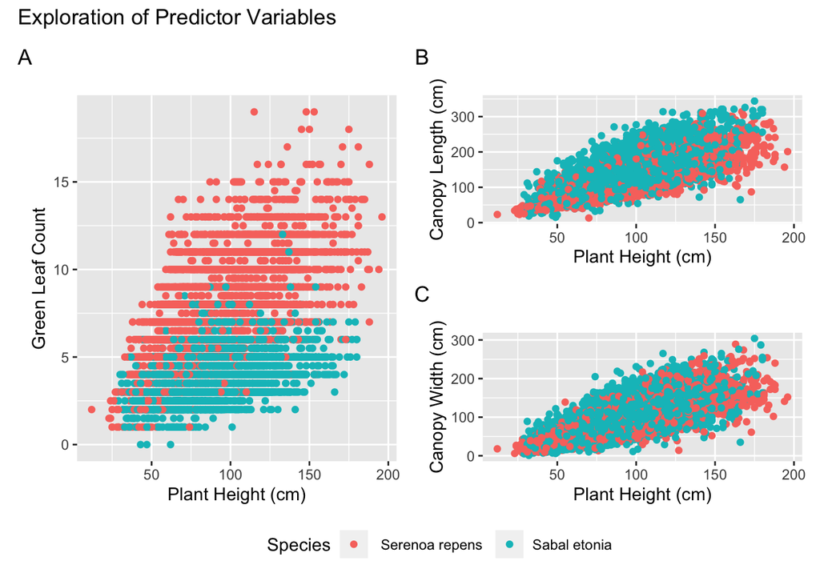

```r
#reading in the data
palmetto <- read_csv(here("data", "palmetto.csv")) %>%
  #selecting species and chosen variables
  select(species, height:green_lvs) %>%
  #making species a factor
   mutate(species = as.factor(species)) %>%
  #dropping na and other
  drop_na()






#making a plot with height and canpy width
plot1 <- ggplot(data = palmetto, aes(x = height, y = width)) +
  geom_point(aes(color = species)) +
  ggtitle("") +
 labs(x = "Plant Height (cm)", y = "Canopy Width (cm)") +
  scale_color_discrete(name = "Species", labels = c("1" = " Serenoa repens ", "2" = "Sabal etonia"))

#making a plot with height and canopy length
plot2 <- ggplot(data = palmetto, aes(x = height, y = length)) +
  geom_point(aes(color = species))  +
  ggtitle("") +
 labs(x = "Plant Height (cm)", y = "Canopy Length (cm)") +
  scale_color_discrete(name = "Species", labels = c("1" = " Serenoa repens ", "2" = "Sabal etonia"))


#making a plot with height and leaf count
plot3 <- ggplot(data = palmetto, aes(x = height, y = green_lvs)) +
  geom_point(aes(color = species)) +
  ggtitle("") +
 labs(x = "Plant Height (cm)", y = "Green Leaf Count") +
    scale_color_discrete(name = "Species", labels = c("1" = " Serenoa repens ", "2" = "Sabal etonia"))



#patching together the plots
plot_patch <- plot3  + plot2  / plot1 +plot_layout(guides = 'collect') & theme( legend.position = 'bottom')


#adding plot annotations A and B
 plot_patch +  plot_annotation("Exploration of Predictor Variables",
  tag_levels = "A")
```

*Figure 1*: Preliminary data observations across variables.

**A:** Comparing plant height and total green leaf count. *S. repens* appears to higher green leaf counts compared to *S. etonia* per unit of height.

**B:** Comparing plant height and canopy length. *S. repens* appears to have slightly smaller canopy length measurements compared to *S. etonia* per unit of height.

**C:** Comparing plant height canopy width. Appears to be much overlap between species.

Based off of the initial data visualization, canopy length and green leaf count are going to be the two most predicting variables determining the type of species. Height and width show significant overlap across both species where as canopy length and green leaf count yield two distinct patterns for both species.

#### Binary Logistic Regression Modeling

```r
    #creaitng the model input for model 1
    f1 <- species ~ height + length + width + green_lvs

    plant_blr1 <- glm(formula = f1,
                    data = palmetto,
                    family = "binomial")

    #visualizing the model
    blr1_tidy <- broom::tidy(plant_blr1)


    #creaitng the model input for model 2
    f2 <- species ~ height + width + green_lvs

    plant_blr2 <- glm(formula = f2,
                    data = palmetto,
                    family = "binomial")

    #visualizing the model
    blr2_tidy <- broom::tidy(plant_blr2)
```

### AIC and BIC

```r
# Listing the AIC values
AIC_list<-c(AIC(plant_blr1), AIC(plant_blr2))
BIC_list <- c(BIC(plant_blr1), BIC(plant_blr2))

# merging data and selecting specific columns
model_output <-rbind(data.frame(glance(plant_blr1)),data.frame(glance(plant_blr2)))

# calculate delta AIC or the distance in AIC from the lowest value (the best model) and the other models.
model_output <- mutate(model_output, delta.AIC = AIC-min(AIC_list))
model_output <- mutate(model_output, delta.BIC = BIC-min(BIC_list))
model_output$model<-c( "Model 1","Model 2")
model_output<-model_output[,c("model", "AIC", "delta.AIC", "BIC", "delta.BIC" )]


kable(model_output, format = "markdown", digits = 3, caption = "*Table 1*: Model outputs showing the AIC/BIC values and delta AIC/BIC values for both models.")
```

*Table 1*: Model outputs showing the AIC/BIC values and delta AIC/BIC values for both models.

| model | AIC | delta.AIC | BIC | delta.BIC |
| --- | --- | --- | --- | --- |
| Model 1 | 5194.562 | 0.00 | 5231.635 | 0.000 |
| Model 2 | 5987.472 | 792.91 | 6017.131 | 785.496 |

#### Cross Validation of Models Using Kfold

```r
set.seed(123)


n_folds <- 10
fold_vec <- rep(1:n_folds, length.out = nrow(palmetto))
palmetto_kfold <- palmetto %>%
  mutate(fold = sample(fold_vec, size = n(), replace = FALSE))




results_df <- data.frame()
pred_acc <- function(x, y) {
  accurate <- ifelse(x == y, 1, 0)
  return(mean(accurate, na.rm = TRUE))
}

for(i in 1:n_folds) {
  kfold_test <- palmetto_kfold %>%
    filter(fold == i)
  kfold_train <- palmetto_kfold %>%
    filter(fold != i)

  kfold_blr1 <- glm(f1, data = kfold_train, family = 'binomial')
  kfold_blr2 <- glm(f2, data = kfold_train, family = 'binomial')
  kfold_pred <- kfold_test %>%
    mutate(blr1 = predict(kfold_blr1, kfold_test, type = 'response'),
           blr2 = predict(kfold_blr2, ., type = 'response')) %>%
    mutate(pred1 = ifelse(blr1 > 0.50, '2', '1'),
           pred2 = ifelse(blr2 > 0.50, '2', '1'))
  kfold_accuracy <- kfold_pred %>%
    summarize(blr1_acc = pred_acc(species, pred1),
              blr2_acc = pred_acc(species, pred2))

  results_df <- bind_rows(results_df, kfold_accuracy)
}


results_df <- results_df %>%
  summarize(blr1_acc = mean(blr1_acc),
            blr2_acc = mean(blr2_acc))

colnames(results_df) <- c("BLR1 Accuracy", "BLR2 Accuracy")

kable(results_df,  format = "markdown", digits = 3,caption = "*Table 2*: Prediction accuracy of modelsbased of K fold cross validation test ")
```

*Table 2*: Prediction accuracy of modelsbased of K fold cross validation test

| BLR1 Accuracy | BLR2 Accuracy |
| --- | --- |
| 0.917 | 0.899 |

#### Results

Our final model:
$$\begin{aligned}
\log\left[ \frac { P( \operatorname{species} = \operatorname{2} ) }{ 1 -
P( \operatorname{species} = \operatorname{2} ) } \right] &= \alpha +
\beta_{1}(\operatorname{height}) + \beta_{2}(\operatorname{length}) +
\beta_{3}(\operatorname{width})\ + \\
&\quad \beta_{4}(\operatorname{green\_lvs})
\end{aligned}$$

and with coefficients in place:
$$\begin{aligned}
\log\left[ \frac { \widehat{P( \operatorname{species} = \operatorname{2}
)} }{ 1 - \widehat{P( \operatorname{species} = \operatorname{2} )} }
\right] &= 3.23 - 0.03(\operatorname{height}) +
0.05(\operatorname{length}) + 0.04(\operatorname{width})\ - \\
&\quad 1.91(\operatorname{green\_lvs})
\end{aligned}$$

```r
# converting the odds to the probability of being 1 or 2
blr1_fitted <- plant_blr1 %>%
  broom::augment(type.predict = "response")   %>%
  mutate(species_pred = ifelse(.fitted > 0.5, "2" , "1"))  %>%
  mutate(species_acc = ifelse(species_pred == species, "TRUE", "FALSE"))



#creating a new data frame from blr1_fitted
blr1_final <- blr1_fitted %>%
  #reclassifying species as a character
mutate(species = as.character(species)) %>%
  #grouping by species for following code
  group_by(species) %>%
  #creating new colomns of correct and false classifications of data
 summarize(correct_class = sum(species_acc == "TRUE", na.rm = "TRUE"),
         false_class = sum(species_acc == "FALSE")) %>%
  #calculaitng the percent correct classifications for each species
  mutate(percent_correct = 100*(correct_class/(correct_class + false_class)))
  colnames(blr1_final) <- c("Species", "Correctly Classified", "Falsely Classified", "Percent Correct")

  #renaming 1 and 2 into species names
blr1_final$Species[blr1_final$Species=="1"] <- "Serenoa repens"
blr1_final$Species[blr1_final$Species=="2"] <- "Sabal etonia"


#making a neat table
kable(blr1_final, format = "markdown", digits = 3, caption = "*Table 3:* Correct and false classifications by count of both *Serenoa repens* and *Sabal etonia* species as well as total percent correct for each species. ") %>%
kable_styling(blr1_final, bootstrap_options = "striped", position = "left", full_width = FALSE)
```

*Table 3:* Correct and false classifications by count of both *Serenoa repens* and *Sabal etonia* species as well as total percent correct for each species.

| Species | Correctly Classified | Falsely Classified | Percent Correct |
| --- | --- | --- | --- |
| Serenoa repens | 5548 | 564 | 90.772 |
| Sabal etonia | 5701 | 454 | 92.624 |